# Who Is Justin Jodrey?

2019-03-02

Hi! I’m Justin, a data scientist at [84.51°](https://8451.com/), working on the Health and Wellness team with the [OptUP](https://www.kroger.com/d/optup) app and nutrition scoring, and with pharmacy data.

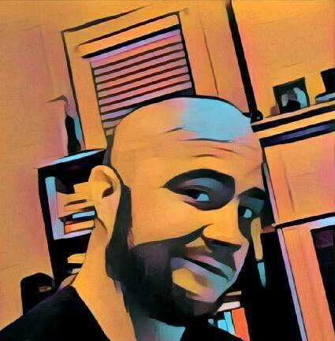

## Academic Background

- B.S. Mathematics with a Minor in Actuarial Science, [Miami University](https://www.miamioh.edu/), Oxford, OH
- M.A.T. Integrated Mathematics Education, [Miami University](https://www.miamioh.edu/), Oxford, OH
- M.S. Business Analytics, [University of Cincinnati](http://www.uc.edu/), Cincinnati, OH

## Professional Background

After graduating from Miami University the first time, I worked for one year as a System and Rating Analyst at [American Modern Insurance](https://www.amig.com/) in Amelia, OH, where I programmed rating algorithms for speciality insurance products. I quickly discovered that I had a passion for teaching high school mathematics and quit my insurance job, attending Miami University full-time to earn my master’s degree in teaching and earn my initial teaching license.

I spent almost a decade teaching almost every middle and high school math/stats course in these school districts:

- Student-taught at [Kings High School](http://www.kingslocal.net/high-school/home-1/-/) in Kings Mills, OH
- 3 years at [Butler High School](http://www.vbcsd.com/1/Home) in Vandalia, OH
- 5 years at [Taylor High School](https://www.threeriversschools.org/) in Cleves, OH

I also taught for the past 3 years at [UC Blue Ash College](https://www.ucblueash.edu/) in the MATH and STAT departments.

At Taylor High School, I began to analyze data and build predictive models on student OGT test scores in order to target future at-risk students and provide interventions. This work led to enrolling in UC’s [MS Business Analytics](https://business.uc.edu/academics/specialized-masters/business-analytics.html) program part-time and eventually returning to the private sector.

## Experience in R

R has been my preferred language/program for 4 years. I use R for a lot of data cleaning and supervised/unsupervised learning, and am beginning my adventure into text mining and NLP this year.

## Experience with Other Analytic Software

I used Excel (and TI calculators) in my before-R era but I currently work in R, SQL, and Python. I have used and at least dabble in:

- SAS
- Tableau
- Arena
- GAMS
- Excel Solver